# Predict racetime Olympic Marathon

Brecht Dewilde

## Introduction

The basis dataset is the historical dataset obtained from Kaggle: dataset. This is a historical dataset containing the outcomes of all the games from Athens 1896 to Rio 2016. The full dataset contains 271 116 rows and 15 columns. Each row corresponds to an individual athlete competing in an individual Olympic event. The columns are:

1. ID - Unique number for each athlete
2. Name - Athlete’s name
3. Sex - M or F
4. Age - Integer
5. Height - In centimeters
6. Weight - In kilograms
7. Team - Team name
8. NOC - National Olympic Committee 3-letter code
9. Games - Year and season
10. Year - Integer
11. Season - Summer or Winter
12. City - Host city
13. Sport - Sport
14. Event - Event
15. Medal - Gold, Silver, Bronze, or NA

Preview of the dataset:

```
##   ID                     Name Sex Age Height Weight           Team NOC
## 1  1                A Dijiang   M  24    180     80          China CHN
## 2  2                 A Lamusi   M  23    170     60          China CHN
## 3  3      Gunnar Nielsen Aaby   M  24     NA     NA        Denmark DEN
## 4  4     Edgar Lindenau Aabye   M  34     NA     NA Denmark/Sweden DEN
## 5  5 Christine Jacoba Aaftink   F  21    185     82    Netherlands NED
## 6  5 Christine Jacoba Aaftink   F  21    185     82    Netherlands NED
##         Games Year Season      City         Sport
## 1 1992 Summer 1992 Summer Barcelona    Basketball
## 2 2012 Summer 2012 Summer    London          Judo
## 3 1920 Summer 1920 Summer Antwerpen      Football
## 4 1900 Summer 1900 Summer     Paris    Tug-Of-War
## 5 1988 Winter 1988 Winter   Calgary Speed Skating
## 6 1988 Winter 1988 Winter   Calgary Speed Skating
##                                Event Medal
## 1        Basketball Men's Basketball  <NA>
## 2       Judo Men's Extra-Lightweight  <NA>
## 3            Football Men's Football  <NA>
## 4        Tug-Of-War Men's Tug-Of-War  Gold
## 5   Speed Skating Women's 500 metres  <NA>
## 6 Speed Skating Women's 1,000 metres  <NA>
```

### Creating a basis dataset

The targetvalue is the race time of the athletes. However, the basis dataset does not contain the actual racetimes, therefore these have to be scraped from another source. The [site](http://www.olympicgamesmarathon.com/results.php) contains the results from all the olympic marathons, a python script is written to scrape these racetimes. Consequently, a dataframe for each year is created and added to the directory: “scraped_times“. First these dataframes are combined into one. Secondly, the basis dataframe is merged to it.

However, these are only male runners. In addition, there are multiple athletes whereof the race time is unknown. Specifically, for the olympics in the past. Athletes whereof the target value is unknown are not valuable for our analysis and will therefore be deleted. The merge condition is as follows:“if there are at least two words in the name vector that match then the rows will be merged together”. We obtain a dataset containing 1032 athletes. This will be used as start point for our analysis.

```
## [1] "marathonM_times"
```

### Adding additional variables based on the available onces

Prevention of data leakage. At this point I have to select a time window in which the features will be calculated.

The variables that will be added are: ** BMI gdp ** ** population **

The kaggle page: “https://www.kaggle.com/chadalee/olympics-data-cleaning-exploration-prediction/data” explains why it can be helpfull to add each of these variables to the dataset.

### First Regression analaysis

#### Linearity assumption

To check the linearity between each dependent and independent variable multiple scatterplots will be created. If non-linear relationships are found, then transformations will be used to adapt.

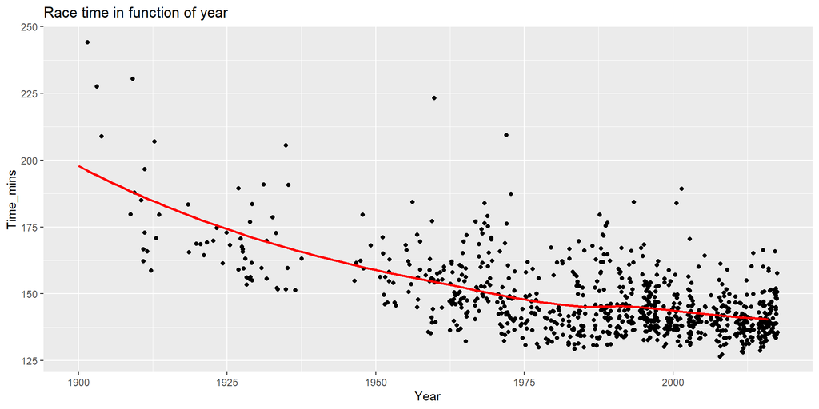

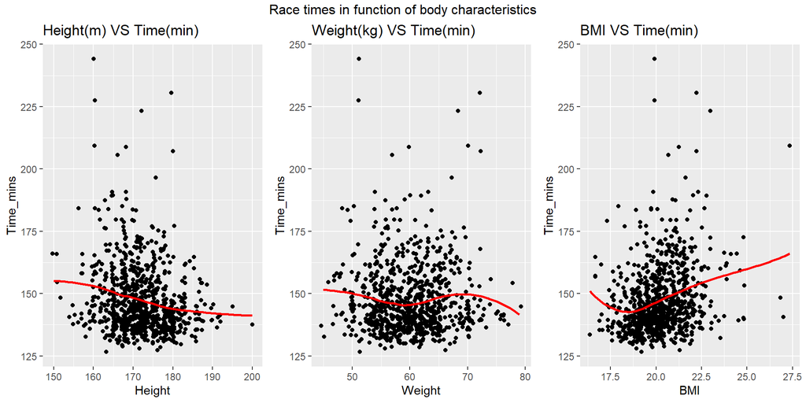

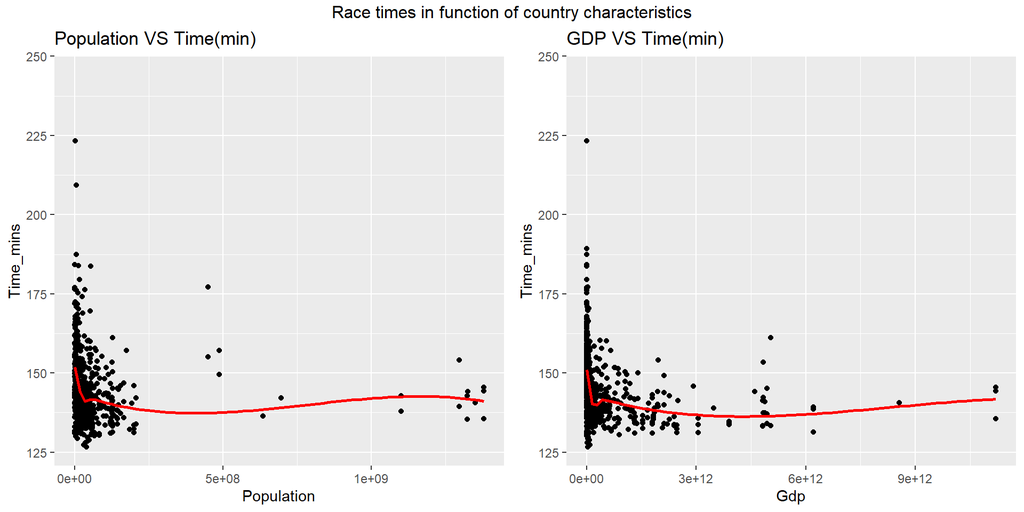

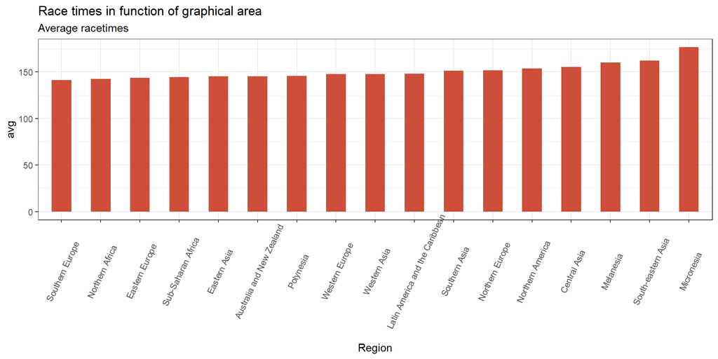

### The score variable

Now an additional variable is added to the dataset. This variable comes from the site : “https://www.worldathletics.org/world-rankings/marathon/men”. This site has created a ‘score metric’, this metric is based on the results from their best two marathons of the last two years (i guess, dive more into this!!!). The idea now is that with this score metric and the other variables that I will be able to predict the first race times.